# Financial Data Analysis on Stocks

## Financial Data Analysis

### Financial Time Series

```python
import pandas as pd
import matplotlib.pyplot as plt
import seaborn as sns
import numpy as np
```

```python
%matplotlib inline
plt.style.use("seaborn")
```

Importing the us stocks dataset (**us_stocks.csv**) and selecting the Adjusted Close (**Adj Close**) for six stocks from **31-12-2015** (incl.) until **31-12-2018** (incl.).

**Ticker Symbols**:

- AXP : American Express
- FB : Facebook
- INTC : Intel
- MCD : McDonalds
- PG : Procter & Gamble
- WMT: Walmart

```python
stocks = pd.read_csv("us_stocks.csv", header=[0,1], index_col = [0], parse_dates = [0]).loc["31-12-2015":"01-01-2019", "Adj Close"]
```

```python
stocks.head()
```

| Date | AXP | FB | INTC | MCD | PG | WMT |
| --- | --- | --- | --- | --- | --- | --- |
| 2015-12-31 | 65.910294 | 104.660004 | 31.437597 | 108.968636 | 71.450706 | 56.722713 |
| 2016-01-04 | 64.052849 | 102.220001 | 31.017828 | 108.452126 | 70.514938 | 56.870766 |
| 2016-01-05 | 63.067310 | 102.730003 | 30.871820 | 109.946350 | 70.739891 | 58.221748 |
| 2016-01-06 | 61.315948 | 102.970001 | 30.187403 | 109.208458 | 70.056053 | 58.804699 |
| 2016-01-07 | 60.763893 | 97.919998 | 29.055828 | 106.681190 | 69.444221 | 60.174198 |

```python
stocks.tail()
```

| Date | AXP | FB | INTC | MCD | PG | WMT |
| --- | --- | --- | --- | --- | --- | --- |
| 2018-12-21 | 90.957733 | 124.949997 | 44.557564 | 174.149994 | 90.256142 | 87.129997 |
| 2018-12-24 | 89.135193 | 124.059998 | 43.315437 | 170.279999 | 86.674469 | 85.820000 |
| 2018-12-26 | 93.457497 | 134.179993 | 45.899059 | 174.029999 | 89.383041 | 90.410004 |
| 2018-12-27 | 94.294075 | 134.520004 | 46.067993 | 175.710007 | 91.297897 | 91.589996 |
| 2018-12-28 | 94.035133 | 133.199997 | 46.455536 | 175.559998 | 90.464493 | 92.129997 |

- **Visualize** the Adjusted Close of the six stocks **over time**!

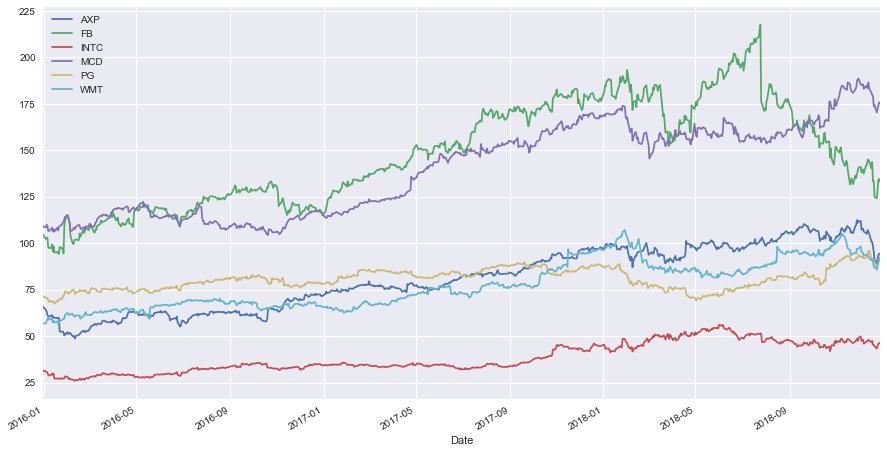

```python
stocks.plot(figsize = (15, 8))
```

- **Visualize** the **normalized** Adjusted Close of the six stocks **over time**, each starting at a **Base Value of 100**!

```python
norm_stocks = stocks.div(stocks.iloc[0]).mul(100)
```

```python
norm_stocks.head()
```

| Date | AXP | FB | INTC | MCD | PG | WMT |
| --- | --- | --- | --- | --- | --- | --- |
| 2015-12-31 | 100.000000 | 100.000000 | 100.000000 | 100.000000 | 100.000000 | 100.000000 |
| 2016-01-04 | 97.181859 | 97.668639 | 98.664755 | 99.526001 | 98.690331 | 100.261012 |
| 2016-01-05 | 95.686586 | 98.155933 | 98.200317 | 100.897243 | 99.005167 | 102.642742 |
| 2016-01-06 | 93.029395 | 98.385245 | 96.023252 | 100.220084 | 98.048091 | 103.670463 |
| 2016-01-07 | 92.191810 | 93.560094 | 92.423820 | 97.900822 | 97.191791 | 106.084838 |

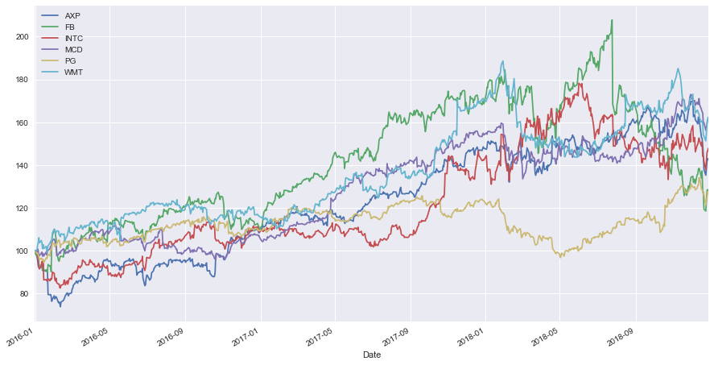

```python
norm_stocks.plot(figsize = (15,8))
```

- Calculating **monthly returns** for all six stocks and create a new **returns** DataFrame!

```python
stock_ret = stocks.resample("BM").last().pct_change().dropna()
```

```python
stock_ret.head()
```

| Date | AXP | FB | INTC | MCD | PG | WMT |
| --- | --- | --- | --- | --- | --- | --- |
| 2016-01-29 | -0.227403 | 0.072138 | -0.099564 | 0.047740 | 0.037677 | 0.082545 |
| 2016-02-29 | 0.038879 | -0.047144 | -0.037703 | -0.046067 | -0.017138 | -0.000302 |
| 2016-03-31 | 0.104714 | 0.067153 | 0.093275 | 0.072446 | 0.025159 | 0.040051 |
| 2016-04-29 | 0.070794 | 0.030500 | -0.063988 | 0.006445 | -0.018639 | -0.023653 |
| 2016-05-31 | 0.005044 | 0.010461 | 0.052274 | -0.035022 | 0.011483 | 0.066221 |

- Calculating the **annualized mean return** and the **annualized standard deviation** of returns for all six stocks!

```python
mean_std = stock_ret.describe().loc[['mean', 'std'], :].T
```

```python
mean_std
```

|  | mean | std |
| --- | --- | --- |
| AXP | 0.012162 | 0.065456 |
| FB | 0.008656 | 0.063183 |
| INTC | 0.012559 | 0.058963 |
| MCD | 0.014179 | 0.041817 |
| PG | 0.007358 | 0.039945 |
| WMT | 0.014997 | 0.054054 |

```python
mean_std['mean'] = mean_std.loc[:, 'mean'] * 12
mean_std['std'] = mean_std.loc[:, 'std'] * np.sqrt(12)
```

```python
mean_std
```

|  | mean | std |
| --- | --- | --- |
| AXP | 0.145942 | 0.226748 |
| FB | 0.103868 | 0.218871 |
| INTC | 0.150712 | 0.204255 |
| MCD | 0.170144 | 0.144859 |
| PG | 0.088297 | 0.138374 |
| WMT | 0.179962 | 0.187247 |

- **Visualizing risk/return** of all six stocks in a (total) risk / return framework. (annualized std on the x-axis, annualized mean returns on the y-axis).  
  Identifying the **best performing** stock and the **worst performing** stock (in terms of **risk / return**)

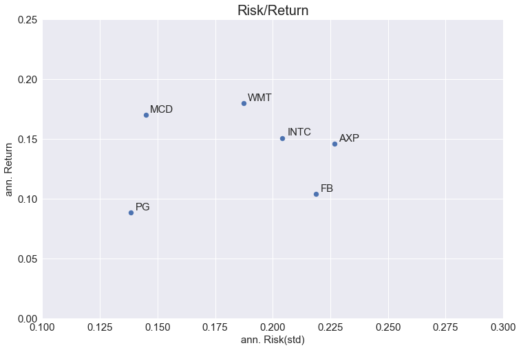

```python
mean_std.plot(kind = "scatter", x = "std", y = "mean", figsize = (12, 8), s = 50, fontsize = 15, xlim = (0.1, 0.3), ylim = (0, 0.25))
for i in mean_std.index:
    plt.annotate(i, xy=(mean_std.loc[i, "std"]+0.002, mean_std.loc[i, "mean"]+0.002), size = 15)
plt.xlabel("ann. Risk(std)", fontsize = 15)
plt.ylabel("ann. Return", fontsize = 15)
plt.title("Risk/Return", fontsize = 20)
plt.show()
```

- **Visualizing** the **correlation matrix** of monthly returns with a **Seaborn Heatmap**. Which stocks-pair shows the **highest (positive) correlation** of monthly returns?

```python
corr = stock_ret.corr()
corr
```

|  | AXP | FB | INTC | MCD | PG | WMT |
| --- | --- | --- | --- | --- | --- | --- |
| AXP | 1.000000 | 0.068655 | 0.306292 | 0.261880 | -0.099335 | -0.048483 |
| FB | 0.068655 | 1.000000 | 0.169326 | 0.069091 | -0.008261 | 0.149272 |
| INTC | 0.306292 | 0.169326 | 1.000000 | 0.084089 | -0.074533 | 0.129686 |
| MCD | 0.261880 | 0.069091 | 0.084089 | 1.000000 | 0.177252 | 0.505501 |
| PG | -0.099335 | -0.008261 | -0.074533 | 0.177252 | 1.000000 | 0.359595 |
| WMT | -0.048483 | 0.149272 | 0.129686 | 0.505501 | 0.359595 | 1.000000 |

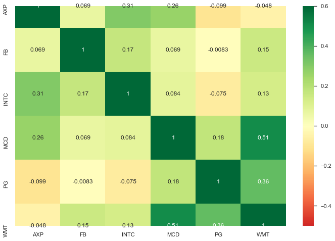

```python
plt.figure(figsize= (12,8))
sns.set(font_scale=1.0)

sns.heatmap(corr, cmap = "RdYlGn", annot = True, vmin = -0.5, vmax = 0.6, center = 0)
plt.show()
```

**Ticker Symbols**:

- AXP : American Express
- FB : Facebook
- INTC : Intel
- MCD : McDonalds
- PG : Procter & Gamble
- WMT: Walmart